# Part 2: Machine Learning

Ignacio Almodóvar

20/01/2022

# First Step

## Download Data

The data chosen for this study has been taken from kaggle. It contains several financial ratios from companies and a column that specifies if the company is in bankruptcy or not.

The data were collected from the Taiwan Economic Journal for the years 1999 to 2009. Company bankruptcy was defined based on the business regulations of the Taiwan Stock Exchange.

```r
setwd("/Users/ignacioalmodovarcardenas/Desktop/Statistical Learning/Statistical_Learning/")
data=read.csv("data.csv")
data$Bankrupt.=as.factor(data$Bankrupt.)
data$Liability.Assets.Flag=as.factor(data$Liability.Assets.Flag)
dim(data)
```

```
## [1] 6819   96
```

We can see that there are 96 different variables. Working with this amount of variables is going to be practically impossible both in terms of understanding of the data set and about computation times. Therefore, I made a brief study about finance and found out which ratios are more useful to find whereas a company is in bankruptcy or not.

```
## [1] "Bankrupt."
## [2] "ROA.C..before.interest.and.depreciation.before.interest"
## [3] "Tax.rate..A."
## [4] "Debt.ratio.."
## [5] "Operating.profit.Paid.in.capital"
## [6] "Cash.Total.Assets"
## [7] "Cash.Flow.to.Equity"
## [8] "Liability.Assets.Flag"
```

## Pre-process and Analyze

First of all I wanted to check if there are any missing values NA in my data set. In order to do that I wrote a function that specifies if there are any missing values, and if so, it says the number of missing values and the column that contains it.

```r
missingValues=function(data){
  count=0
  a=cbind(lapply(lapply(data, is.na), sum))
  for(i in 1:ncol(data)){
    if(a[i]!=0){
      cat("There are", a[i], "missing values in column ", i,"\n" )
      count=count+1
    }
  }
    if(count==0){
      cat("There are No missing values in this dataset")
    }
}

missingValues(data)
```

```
## There are No missing values in this dataset
```

Also, part of the pre-process we are going to split the dataset in training and testing sets.

```r
set.seed(1234)
index1=createDataPartition(y = data_1$Bankrupt.,p=0.6,list = FALSE)
trainSet=data_1[index1,]
testSet=data_1[-index1,]
```

Now, looking for differentiation in groups and other characteristics I am going to look for more information about which variables are the best predictors.

Therefore we are mainly going to use density plot in order to know if the variables might me good for prediction or not.

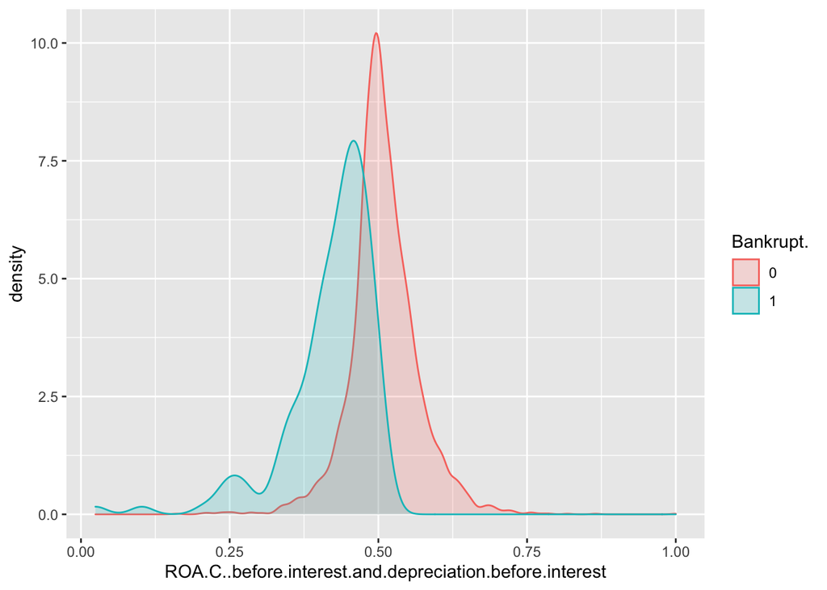

```r
trainSet %>% ggplot(aes(x =ROA.C..before.interest.and.depreciation.before.interest)) +
  geom_density(aes( colour = Bankrupt., fill = Bankrupt.),alpha = 0.2)
```

We can see that using ROAC there is a slight difference on the two populations (Bankcruptcy o not), so we might use this variable for our prediction model.

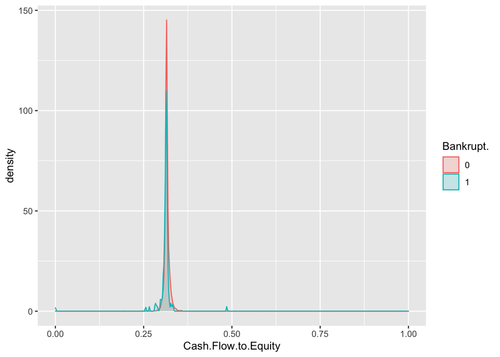

```r
trainSet %>% ggplot(aes(x =Cash.Flow.to.Equity)) +
  geom_density(aes( colour = Bankrupt., fill = Bankrupt.),alpha = 0.2)
```

Using this same process we can conclude that this variable is not going to be a god predictor by herself for our model, as both populations behaviors are quite similar.

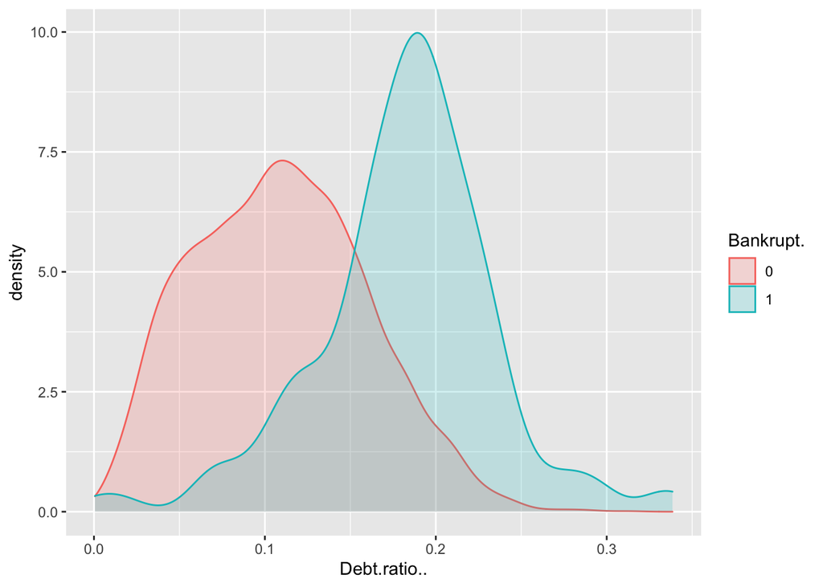

```r
trainSet %>% ggplot(aes(x =Debt.ratio..)) +
  geom_density(aes( colour = Bankrupt., fill = Bankrupt.),alpha = 0.2)
```

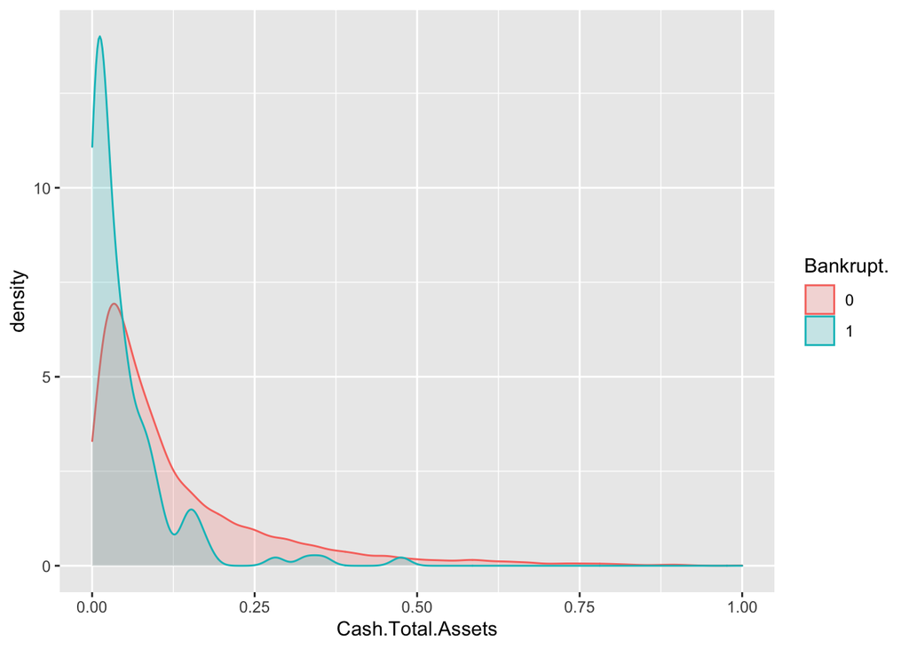

```r
trainSet %>% ggplot(aes(x =Cash.Total.Assets)) +
  geom_density(aes( colour = Bankrupt., fill = Bankrupt.),alpha = 0.2)
```

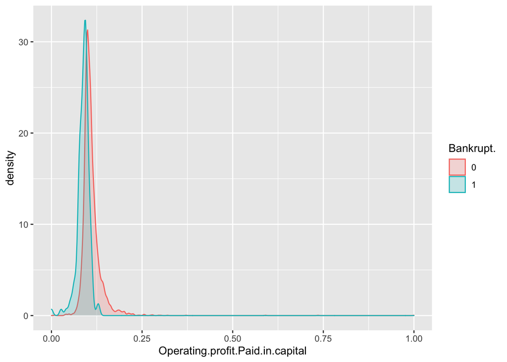

```r
trainSet %>% ggplot(aes(x =Operating.profit.Paid.in.capital)) +
  geom_density(aes( colour = Bankrupt., fill = Bankrupt.),alpha = 0.2)
```

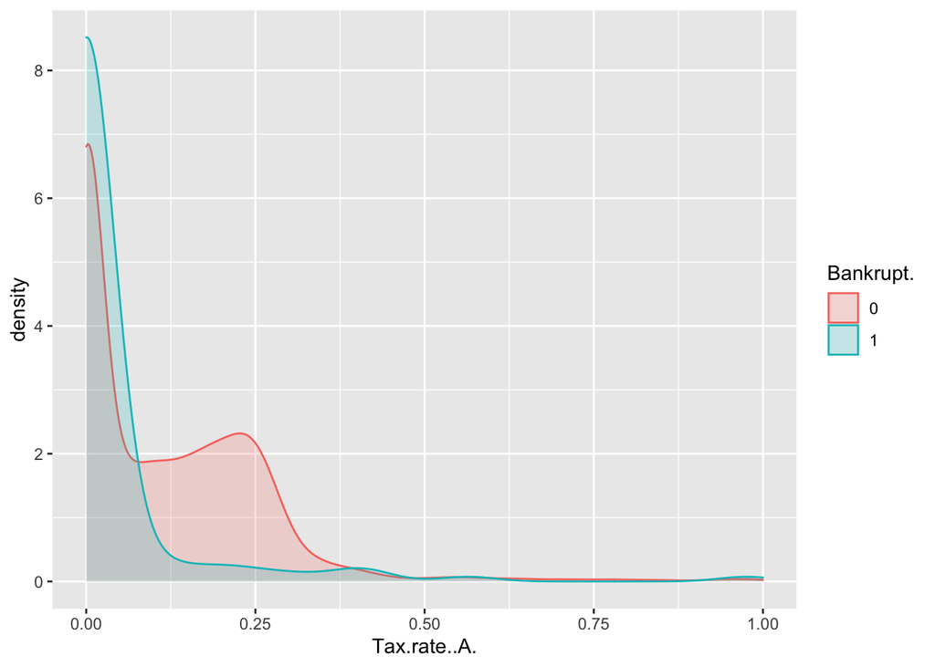

```r
trainSet %>% ggplot(aes(x =Tax.rate..A.)) +
  geom_density(aes( colour = Bankrupt., fill = Bankrupt.),alpha = 0.2)
```

Within all this plots we can also say that the variable “Debt.ratio” can also be a good predictor for companies in bankruptcy.

In order to compare binary variables I decided to do barplots.

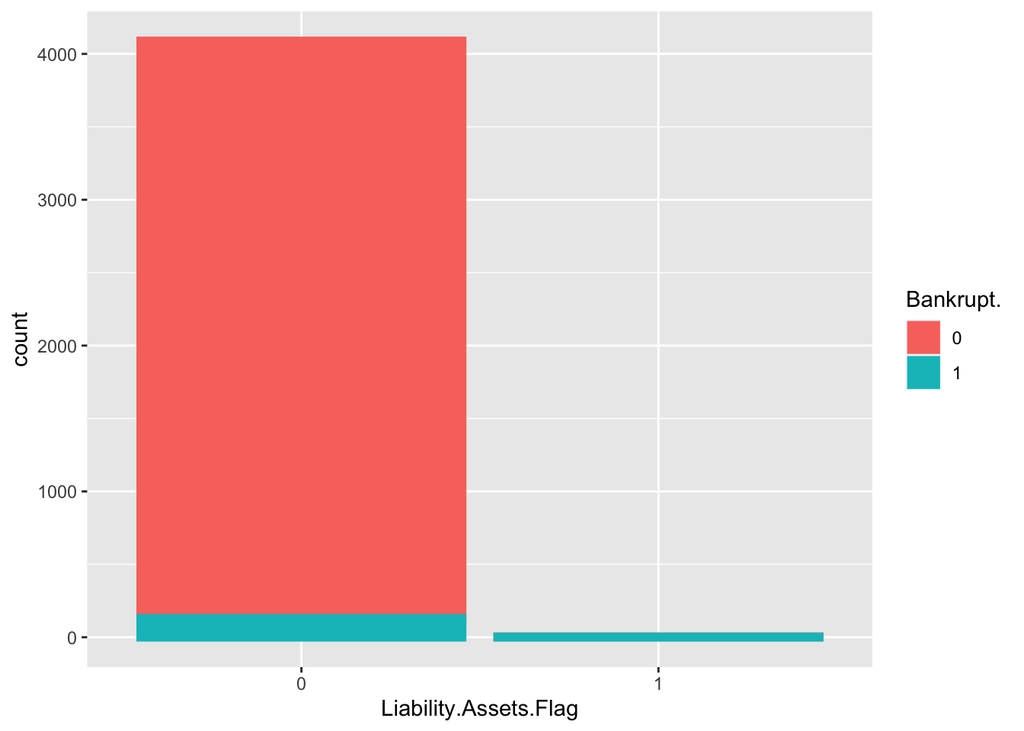

```r
ggplot(trainSet,aes(x=Liability.Assets.Flag,color=Bankrupt.,fill=Bankrupt.)) + geom_bar(size=2)
```

However, one of the problems in this dataset is that our target variable Bankruptcy is not so well balanced, as the number of observations in bankruptcy is way lower than the ones that are not.

```r
as.integer(table(trainSet$Bankrupt.)[2])/as.integer(table(trainSet$Bankrupt.)[1])*100
```

```
## [1] 3.333333
```

We can see that only a 3.3% of the observations are in bankruptcy. As it is quite useless to make predictive models with datasets too unbalanced, we are going to make our training data balanced.

```r
data_balanced_train <- ovun.sample(Bankrupt. ~ ., data = trainSet, method = "over",N = 6092)$data
table(data_balanced_train$Bankrupt.)
```

```
##
##    0    1
## 3960 2132
```

Now let’s create again a train and a control set.

```r
index2=createDataPartition(y = data_balanced_train$Bankrupt.,p=0.8,list = FALSE)
trainSet2=data_balanced_train[index2,]
testSet2=data_balanced_train[-index2,]
```

It is also very useful to do some boxplots in order to see if our data has large number of outliers or not.

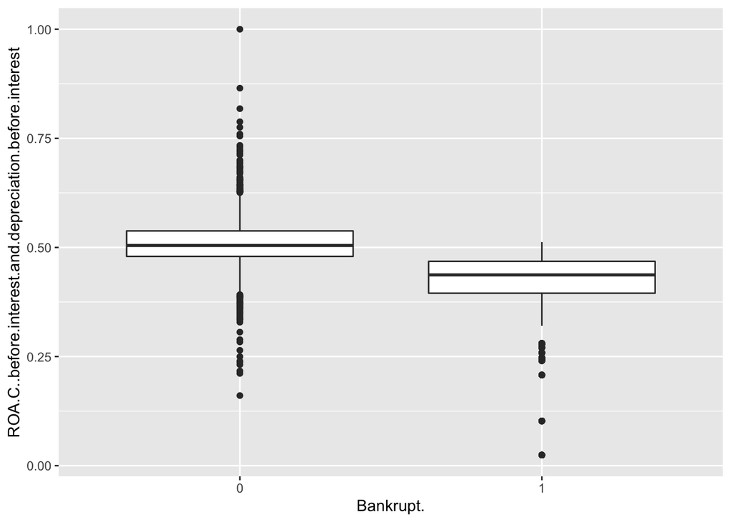

```r
ggplot(trainSet2,aes(x=Bankrupt.,
                y = ROA.C..before.interest.and.depreciation.before.interest)) +
  geom_boxplot()
```

As it can be seen there are a few of them, therefore we are going to save an index of outliers just in case I need to remove it in any case of the analysis.

```r
outliers <- boxplot(trainSet2$ROA.C..before.interest.and.depreciation.before.interest,
                    plot=FALSE)$out
```

Another way to find which variables might be good predictors we can use pairs and see the correlation between the different groups.

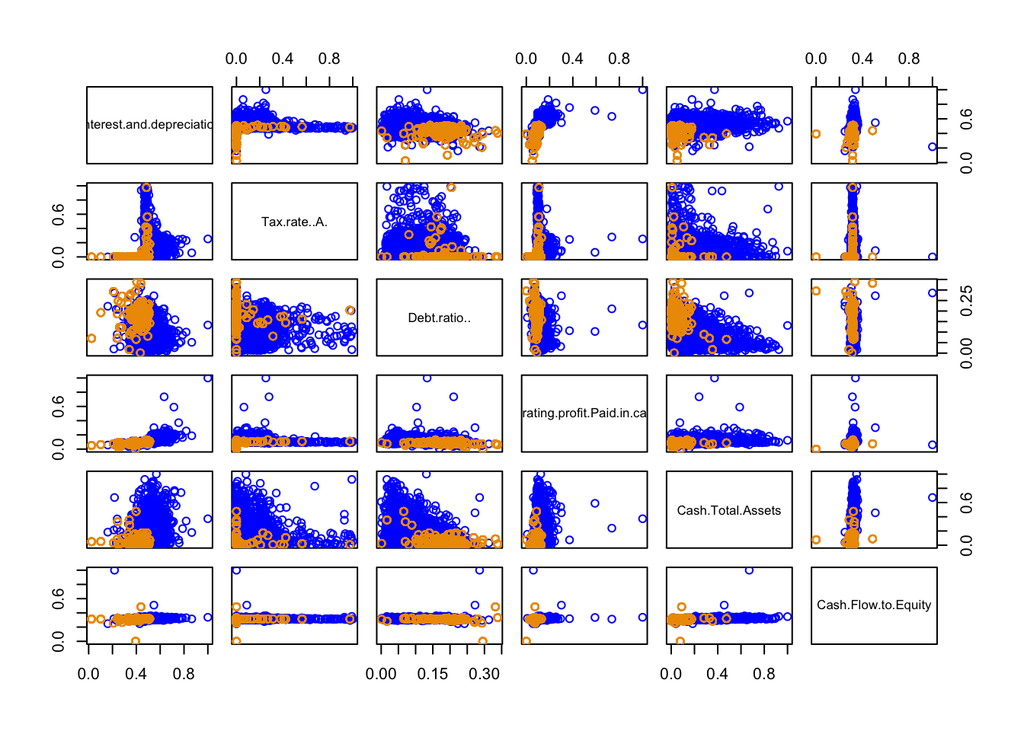

```r
pairs(trainSet2[,2:7],pch=21,col=c("blue","orange2")[trainSet2$Bankrupt.])
```

As it can be seen, most of the variables do split the observations in two groups. Even though there is no linear relationship between any of them, all of them differentiates the bankruptcy observations in one extreme of the scatter plot. Indeed we still can see that the best continuous predictors are the variables ROAC and Debt.ratio.

Other useful plots to visualize classification based on predictors are the ones given by QDA and LDA

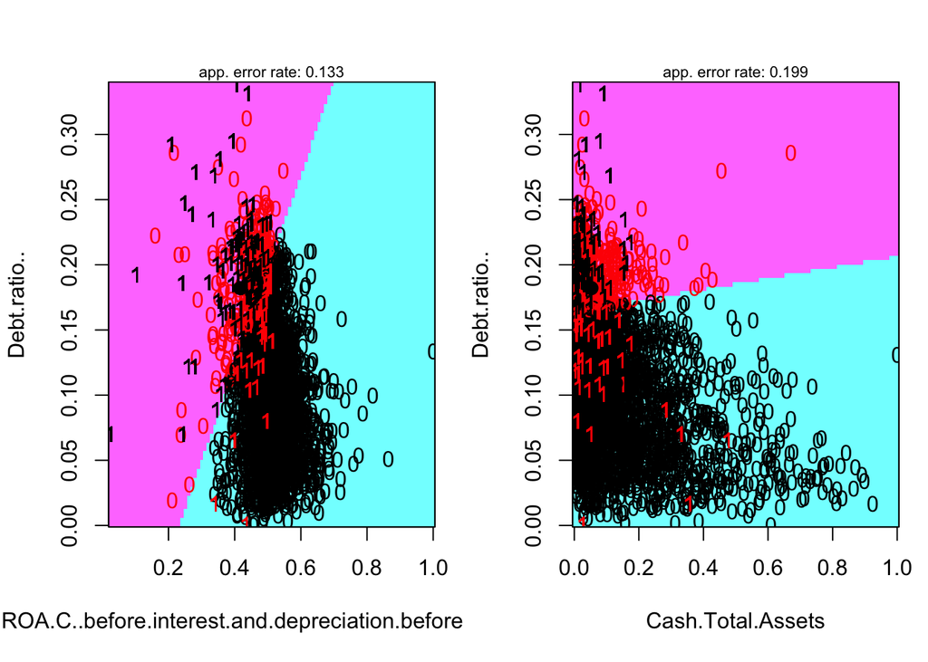

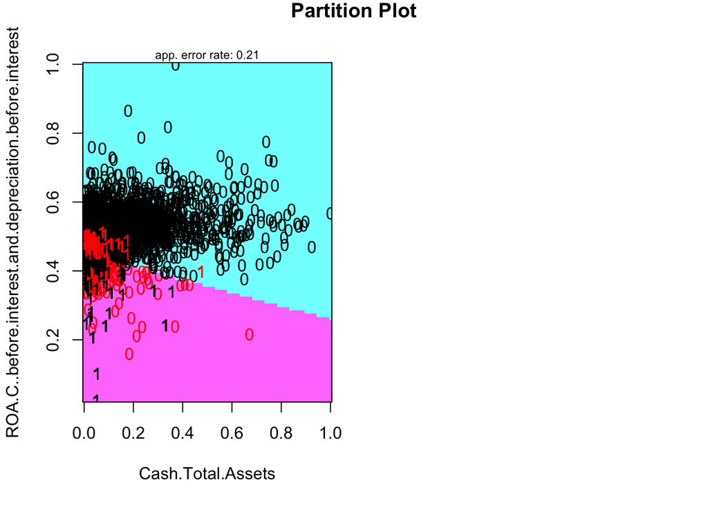

```r
partimat(Bankrupt. ~ Debt.ratio.. + ROA.C..before.interest.and.depreciation.before.interest +
           Cash.Total.Assets ,data=trainSet2,method="lda",)
```

Now using QDA with the same variables:

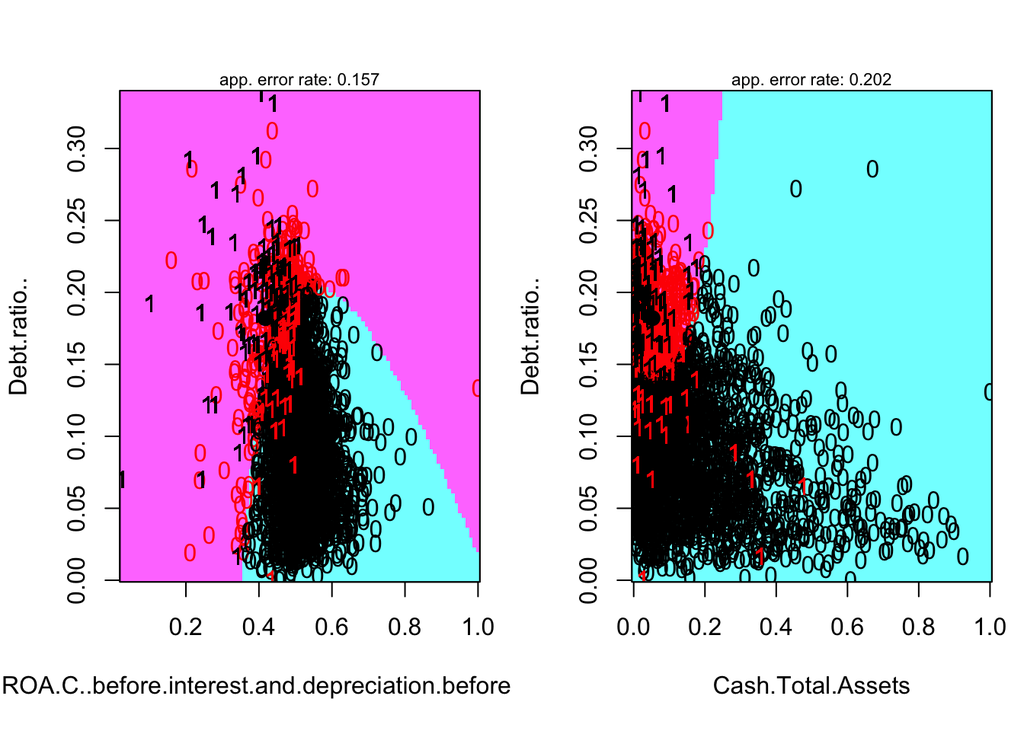

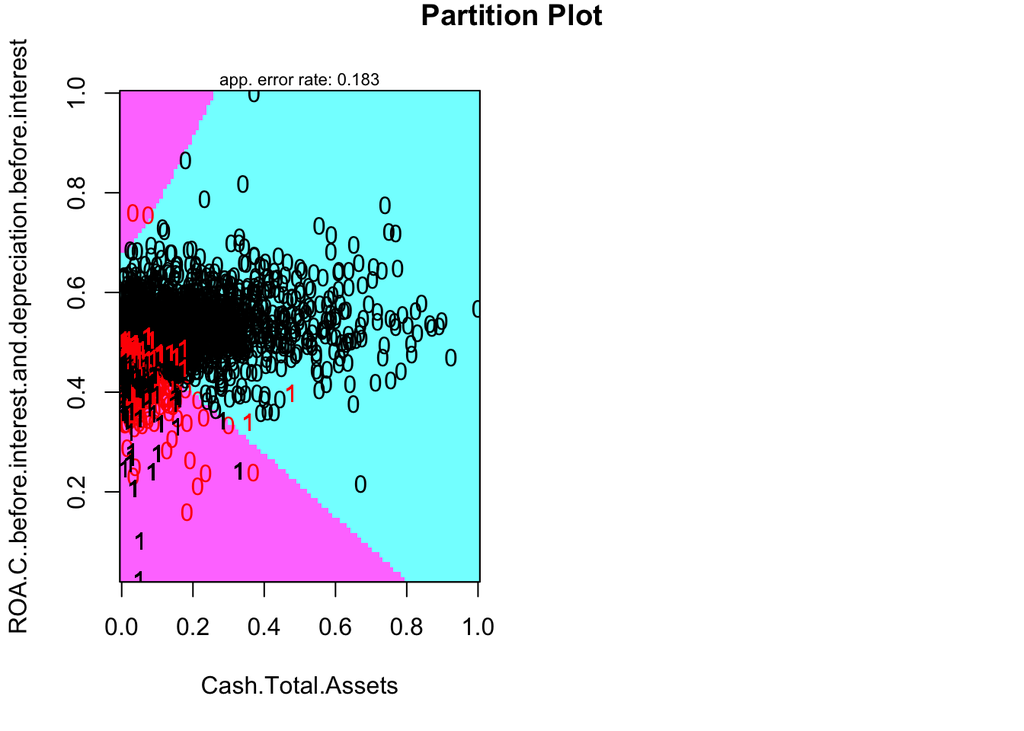

```r
partimat(Bankrupt. ~ Debt.ratio.. + ROA.C..before.interest.and.depreciation.before.interest +
           Cash.Total.Assets ,data=trainSet2,method="qda",)
```

As it can be seen, these variables are actually not bad at all predictors using these methods. Even thought there are a lot of points that are not being well-classified, this methods have potential and we could use them to predict our data

## Classification modeling

As our target is a binary variable, we are going to first start building our model by using Logistic Regression.

```r
log.fit = vglm(Bankrupt. ~ Debt.ratio.., family=multinomial(refLevel=1), data=trainSet2)
prob.test = predict(log.fit, newdata=testSet2, type="response")
pred.test <- as.factor(levels(testSet2$Bankrupt.)[max.col(prob.test)])
ConfMat = table(pred.test,testSet2$Bankrupt.)
ConfMat
```

```
##
## pred.test   0   1
##         0 691 151
##         1 101 275
```

```r
n = length(testSet2$Bankrupt.)
prop.errors <- (n - sum(diag(ConfMat))) / n
prop.errors
```

```
## [1] 0.2068966
```

```r
accuracy <- sum(diag(ConfMat)) / n
accuracy
```

```
## [1] 0.7931034
```

Building our logistic model with just one of our variables already gives a pretty good accuracy rate. However, the error is still quite high. We have to try to make the model being able to predict more companies that are in bankruptcy as it.

As the results obtained are promising, I am going to carry on the modeling using logistic regression, but now using all the variables in our training set.

```r
log.fit = vglm(Bankrupt. ~ ., family=multinomial(refLevel=1), data=trainSet2)
prob.test = predict(log.fit, newdata=testSet2, type="response")
pred.test <- as.factor(levels(testSet2$Bankrupt.)[max.col(prob.test)])
confusionMatrix(pred.test,testSet2$Bankrupt.)
```

```
## Confusion Matrix and Statistics
##
##           Reference
## Prediction   0   1
##          0 724  88
##          1  68 338
##
##                Accuracy : 0.8719
##                  95% CI : (0.8518, 0.8902)
##     No Information Rate : 0.6502
##     P-Value [Acc > NIR] : <2e-16
##
##                   Kappa : 0.7153
##
##  Mcnemar's Test P-Value : 0.1282
##
##             Sensitivity : 0.9141
##             Specificity : 0.7934
##          Pos Pred Value : 0.8916
##          Neg Pred Value : 0.8325
##              Prevalence : 0.6502
##          Detection Rate : 0.5944
##    Detection Prevalence : 0.6667
##       Balanced Accuracy : 0.8538
##
##        'Positive' Class : 0
##
```

The model obtained is actually pretty good already, both Kappa and Accuracy indicators have a good rate.

Now, let’s try using the functions included in the library CARET. We can use a cross validation algorithm to improve our prediction. In addition, as we want to improve the kappa and not the accuracy due to the fact that our data is not perfectly balanced, we can specify it in the metric.

```r
ctrl <- trainControl(method = "repeatedcv", repeats = 4,number = 7)
lrFit <- train(Bankrupt. ~ .,
                method = "glmnet",
                family = "binomial",
                data = testSet2,
                preProcess = c("center","scale"),
                tuneGrid = expand.grid(alpha = seq(0, 2, 0.1), lambda = seq(0, .1, 0.01)),
                metric = "Kappa",
                trControl = ctrl)
```

```r
lrPred = predict(lrFit, testSet2)
confusionMatrix(lrPred, testSet2$Bankrupt.)
```

```
## Confusion Matrix and Statistics
##
##           Reference
## Prediction   0   1
##          0 722  90
##          1  70 336
##
##                Accuracy : 0.8686
##                  95% CI : (0.8484, 0.8871)
##     No Information Rate : 0.6502
##     P-Value [Acc > NIR] : <2e-16
##
##                   Kappa : 0.708
##
##  Mcnemar's Test P-Value : 0.1331
##
##             Sensitivity : 0.9116
##             Specificity : 0.7887
##          Pos Pred Value : 0.8892
##          Neg Pred Value : 0.8276
##              Prevalence : 0.6502
##          Detection Rate : 0.5928
##    Detection Prevalence : 0.6667
##       Balanced Accuracy : 0.8502
##
##        'Positive' Class : 0
##
```

As you can see, the prediction model obtained is very promising and behaves quite good. Nevertheless we are now going to build other models with different methods seen in class to see if we can also build good predictions with them.

First of all we are going to use LDA.

```r
lda.model <- lda(Bankrupt. ~ ., data=trainSet2,prior=c(0.5,0.5))
probability = predict(lda.model, newdata=testSet2)$posterior
prediction = predict(lda.model, newdata=testSet2)$class
confusionMatrix(prediction, testSet2$Bankrupt.)
```

```
## Confusion Matrix and Statistics
##
##           Reference
## Prediction   0   1
##          0 677  65
##          1 115 361
##
##                Accuracy : 0.8522
##                  95% CI : (0.831, 0.8717)
##     No Information Rate : 0.6502
##     P-Value [Acc > NIR] : < 2e-16
##
##                   Kappa : 0.6837
##
##  Mcnemar's Test P-Value : 0.00026
##
##             Sensitivity : 0.8548
##             Specificity : 0.8474
##          Pos Pred Value : 0.9124
##          Neg Pred Value : 0.7584
##              Prevalence : 0.6502
##          Detection Rate : 0.5558
##    Detection Prevalence : 0.6092
##       Balanced Accuracy : 0.8511
##
##        'Positive' Class : 0
##
```

Actually the accuracy obtained is quite surprising. Nevertheless we can see that again, the kappa is quite low and it directly affects to the amount of companies in bankruptcy predicted.

Trying with caret and using the cross validation method the model might improve.

```r
ldaFit <- train(Bankrupt. ~ .,
                method = "lda",
                data = trainSet2,
                preProcess = c("center", "scale"),
                metric = "Accuracy",
                trControl = ctrl)

ldaPred = predict(ldaFit, testSet2)
confusionMatrix(ldaPred,testSet2$Bankrupt.)
```

```
## Confusion Matrix and Statistics
##
##           Reference
## Prediction   0   1
##          0 725  87
##          1  67 339
##
##                Accuracy : 0.8736
##                  95% CI : (0.8536, 0.8917)
##     No Information Rate : 0.6502
##     P-Value [Acc > NIR] : <2e-16
##
##                   Kappa : 0.719
##
##  Mcnemar's Test P-Value : 0.1258
##
##             Sensitivity : 0.9154
##             Specificity : 0.7958
##          Pos Pred Value : 0.8929
##          Neg Pred Value : 0.8350
##              Prevalence : 0.6502
##          Detection Rate : 0.5952
##    Detection Prevalence : 0.6667
##       Balanced Accuracy : 0.8556
##
##        'Positive' Class : 0
##
```

Surprisingly, this model is the best one so far, as it has both accuracy and kappa rates slightly higher than the ones obtained with the logistic regression.

Now, let’s try with QDA

```r
qda.model <- qda(Bankrupt. ~ ., data=trainSet2,prior=c(0.5,0.5))
prediction = predict(qda.model, newdata=testSet2)$class
confusionMatrix(prediction, testSet2$Bankrupt.)
```

```
## Confusion Matrix and Statistics
##
##           Reference
## Prediction   0   1
##          0 760 181
##          1  32 245
##
##                Accuracy : 0.8251
##                  95% CI : (0.8026, 0.8461)
##     No Information Rate : 0.6502
##     P-Value [Acc > NIR] : < 2.2e-16
##
##                   Kappa : 0.5817
##
##  Mcnemar's Test P-Value : < 2.2e-16
##
##             Sensitivity : 0.9596
##             Specificity : 0.5751
##          Pos Pred Value : 0.8077
##          Neg Pred Value : 0.8845
##              Prevalence : 0.6502
##          Detection Rate : 0.6240
##    Detection Prevalence : 0.7726
##       Balanced Accuracy : 0.7674
##
##        'Positive' Class : 0
##
```

Using caret:

```r
qdaFit <- train(Bankrupt. ~ .,
                method = "qda",
                data = trainSet2,
                preProcess = c("center", "scale"),
                metric = "Accuracy",
                trControl = ctrl)
```

```r
qdaPred = predict(qdaFit, testSet2)
confusionMatrix(qdaPred,testSet2$Bankrupt.)
```

```
## Confusion Matrix and Statistics
##
##           Reference
## Prediction   0   1
##          0 774 277
##          1  18 149
##
##                Accuracy : 0.7578
##                  95% CI : (0.7327, 0.7816)
##     No Information Rate : 0.6502
##     P-Value [Acc > NIR] : 3.417e-16
##
##                   Kappa : 0.3805
##
##  Mcnemar's Test P-Value : < 2.2e-16
##
##             Sensitivity : 0.9773
##             Specificity : 0.3498
##          Pos Pred Value : 0.7364
##          Neg Pred Value : 0.8922
##              Prevalence : 0.6502
##          Detection Rate : 0.6355
##    Detection Prevalence : 0.8629
##       Balanced Accuracy : 0.6635
##
##        'Positive' Class : 0
##
```

The results obtained are not bad at all, however, I have been obtaining better predictions with the models used before. Therefore, we can conclude that QDA is not a good method to predict for this dataset.